# Time Series Modeling and Filtering Course Final Report

Minzhe Zhang

2017/5/2

### 1. Reserve Bank of Australia

#### a) ACF and PACF

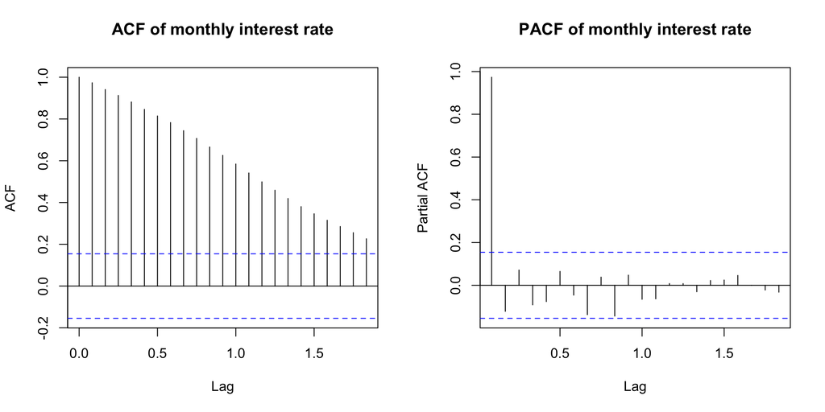

```r
bank.data <- read.table("ReserveBankofAusatraliadata.txt")
bank.data <- ts(bank.data[,1], frequency = 12, start = c(1981, 1), names = "Monthly interest rate")
bank.ts <- window(bank.data, end = c(1994, 5))
bank.test.ts <- window(bank.data, start = c(1994, 5))
par(mfrow = c(1, 2))
acf(bank.ts, main = "ACF of monthly interest rate")
pacf(bank.ts, main = "PACF of monthly interest rate")
```

#### b) Differencing

From the time series plots, we see the original time series is not stationary, but after differencing it is stationary. From acf and pacf, we do not see obvious AR and MA order.

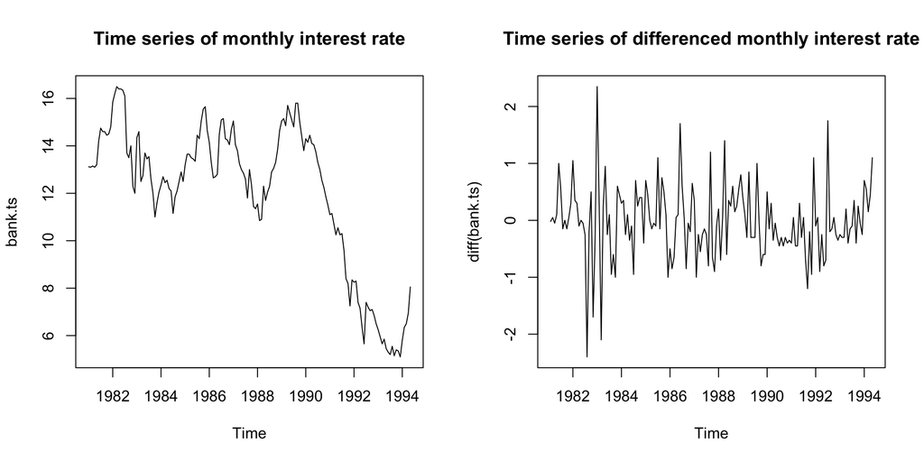

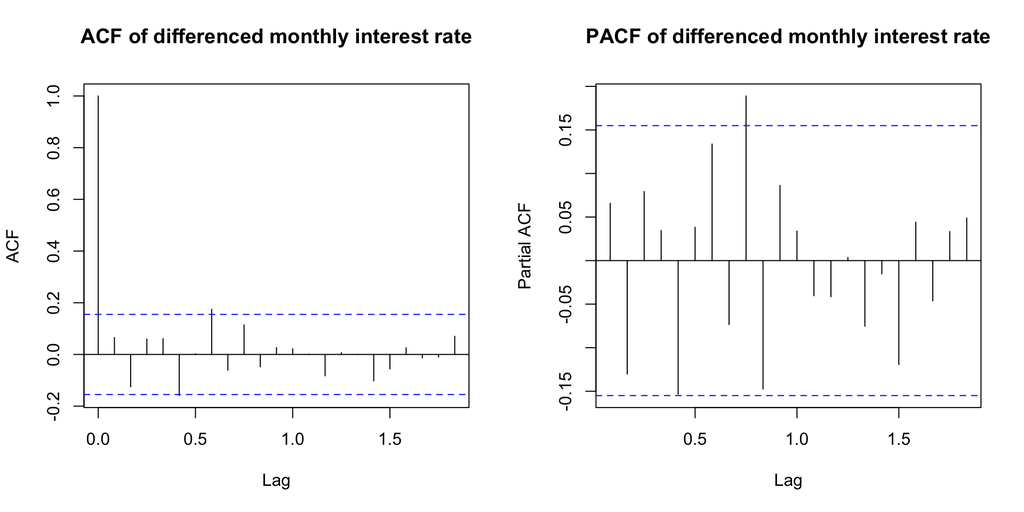

```r
par(mfrow = c(1, 2))
plot.ts(bank.ts, main = "Time series of monthly interest rate")
plot.ts(diff(bank.ts), main = "Time series of differenced monthly interest rate")
acf(diff(bank.ts), main = "ACF of differenced monthly interest rate")
pacf(diff(bank.ts), main = "PACF of differenced monthly interest rate")
```

#### c) ARMA

Based on the acf and pacf plot, we initially propose a ARIMA(0,1,0) model, which is just random walk.

```r
library(tseries)
arima010 <- arima(bank.ts, order = c(0,1,0))
```

#### d) Model comparison

We compare the previous model with ARIMA(p,d,q), p, d, q are chosen between [0,2]. Based on AIC and log likelihood criteria, ARIMA(2,1,2) has the maximum log likelihood and minimum AIC. Therefore, we choose it as the final model.

```r
model <- c()
for (p in c(0,1,2)) {
    for (d in c(0,1,2)) {
        for (q in c(0,1,2)) {
            do.call("<-", list(paste(c("arima", p, d, q), collapse = ""), arima(bank.ts, order = c(p, d, q))))
            model <- c(model, paste(c("arima", p, d, q), collapse = ""))
        }
    }
}
sigma2 <- sapply(paste(model, "$sigma2", sep=""), function(x) eval(parse(text = x)))
loglik <- sapply(paste(model, "$loglik", sep=""), function(x) eval(parse(text = x)))
aic <- sapply(paste(model, "$aic", sep=""), function(x) eval(parse(text = x)))
model.comp <- data.frame(sigma2 = sigma2, loglik = loglik, aic = aic, row.names = model)
model.comp$" " <- rep("", nrow(model.comp))
model.comp[which.min(model.comp$aic), 4] <- "<- selected"
model.comp
```

```
##             sigma2    loglik      aic
## arima000 9.6173368 -410.6663 825.3326
## arima001 2.9122633 -315.5138 637.0276
## arima002 1.3295804 -253.0754 514.1507
## arima010 0.4089244 -155.4922 312.9843
## arima011 0.4062593 -154.9736 313.9471
## arima012 0.4002028 -153.7853 313.5706
## arima020 0.7589145 -203.6799 409.3597
## arima021 0.4104870 -157.3609 318.7218
## arima022 0.4080174 -156.7921 319.5842
## arima100 0.4041545 -157.0879 320.1758
## arima101 0.4005604 -156.3777 320.7555
## arima102 0.3957700 -155.4296 320.8592
## arima110 0.4069632 -155.1100 314.2200
## arima111 0.3966280 -153.1474 312.2949
## arima112 0.4001065 -153.7660 315.5319
## arima120 0.6395851 -190.1645 384.3291
## arima121 0.4086906 -156.9393 319.8786
## arima122 0.3981983 -154.9918 317.9836
## arima200 0.4014423 -156.5516 321.1032
## arima201 0.3916910 -154.6814 319.3628
## arima202 0.3916299 -154.6657 321.3314
## arima210 0.4002957 -153.8048 313.6097
## arima211 0.3990733 -153.5638 315.1275
## arima212 0.3692203 -148.2142 306.4284 <- selected
## arima220 0.5230665 -174.3742 354.7484
## arima221 0.4016664 -155.6961 319.3922
## arima222 0.4005095 -155.4472 320.8944
```

#### e) Diagnostics

From the diagnostic plot, we do not see obvious violation of homoscedasticity. No strong autocorrelation is seen in the residual time series though lag 7 just touch the significant level. Ljung–Box test also does not show any significant serial correlation. QQ-plot show residuals are roughly normally distributed.

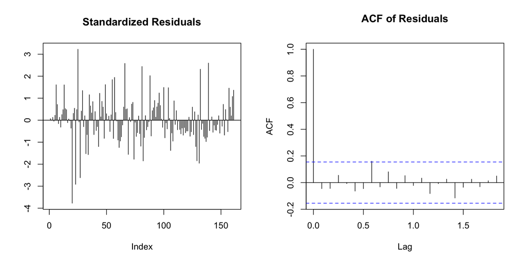

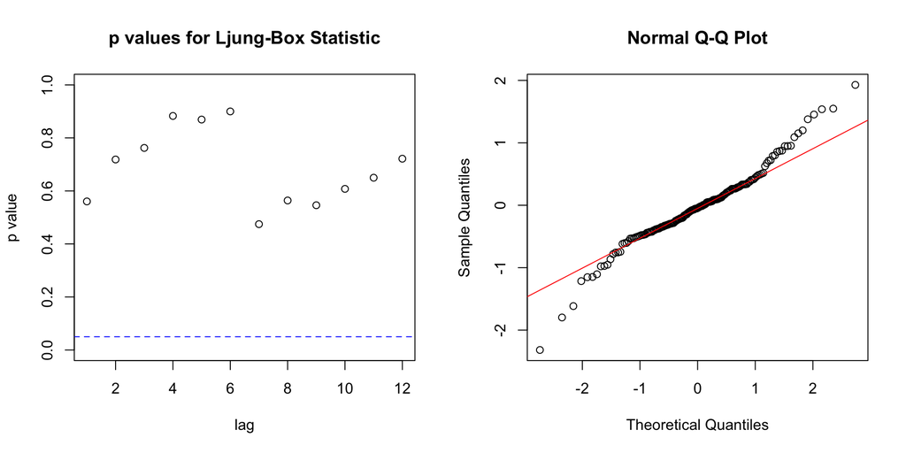

```r
par(mfrow = c(1, 2))
plot(scale(arima212$residuals), type = "h", ylab = "", main = "Standardized Residuals")
abline(h = 0)
acf(arima212$residuals, main = "ACF of Residuals")
plot(x = 1:12,
     y = sapply(1:12, function(x) Box.test(arima212$residuals, type = "Ljung-Box", lag = x)$p.value),
     main = "p values for Ljung-Box Statistic",
     xlab = "lag",
     ylab = "p value",
     ylim = c(0, 1))
abline(h = 0.05, lty = 2, col = "blue")
qqnorm(arima212$residuals)
qqline(arima212$residuals, col = "red")
```

#### f) Forecast

The prediction the monthly interest rates for June, July and August of 1994 and their corresponding 99% prediction intervals are showed below. Plot show focast, prediction interval and real value of the three monthes.

```
##          Point Forecast    Lo 99     Hi 99
## Jun 1994       8.070708 6.505399  9.636017
## Jul 1994       7.934181 5.508238 10.360124
## Aug 1994       8.085930 5.093093 11.078768
```

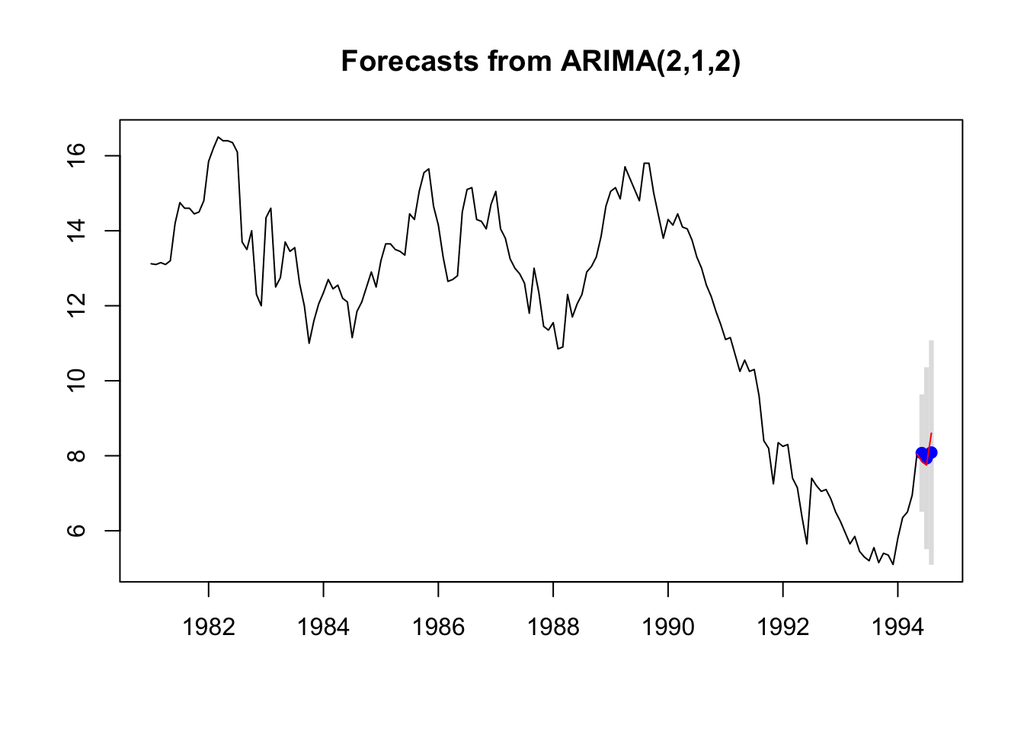

```r
library(forecast)
bank.fcst <- forecast(arima212, h = 3, level = 99)
plot(bank.fcst)
lines(bank.test.ts, col = "red")
bank.fcst
```

#### g) Conclusion

The prediction result of ARIMA(2,1,2) are close to the real values, suggest a relative good predictive power of the obtained model. However, diagnostic plots show there may exist some unexplained autocorrelation in the residuals. The forecast may be further improved by using more complex model.

### 2. Dow-Jones industrial index

#### a) ACF and PACF

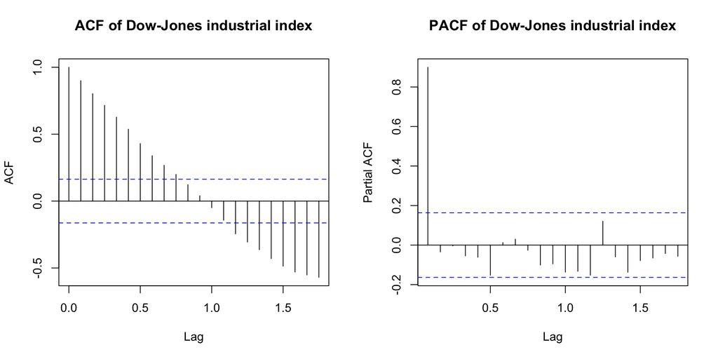

```r
DJ.data <- read.table("Dow-Jones.industrial.index.txt", row.names = 1)
DJ.data <- ts(DJ.data[,1], frequency = 12, start = c(1968, 8), names = "Dow-Jones industrial index")
DJ.ts <- window(DJ.data, end = c(1980, 7))
DJ.test.ts <- window(DJ.data, start = c(1980,7))
par.default <- par()
par(mfrow = c(1, 2))
acf(DJ.ts, main = "ACF of Dow-Jones industrial index")
pacf(DJ.ts, main = "PACF of Dow-Jones industrial index")
```

#### b) Differencing

After differencing, the time series is more stationary than original series. But only lag in 14 month reached the significant level in acf and pacf plots, so probably there is no AR or MA process.

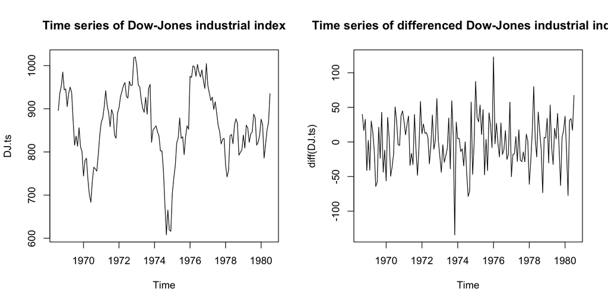

```r
par(mfrow = c(1, 2))
plot.ts(DJ.ts, main = "Time series of Dow-Jones industrial index")
plot.ts(diff(DJ.ts), main = "Time series of differenced Dow-Jones industrial index")
```

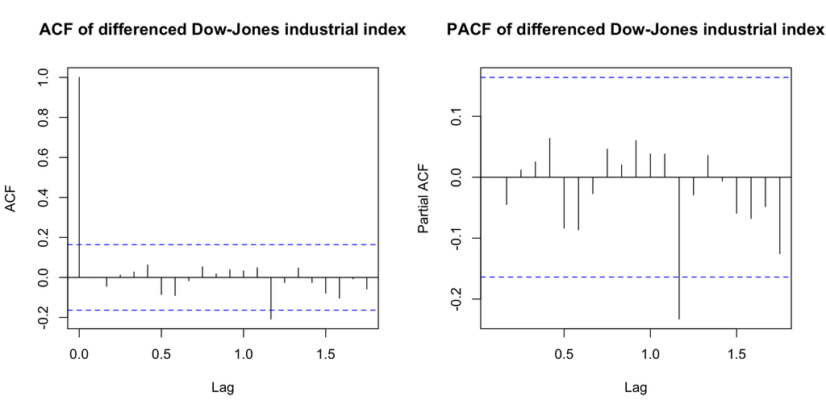

```r
acf(diff(DJ.ts), main = "ACF of differenced Dow-Jones industrial index")
pacf(diff(DJ.ts), main = "PACF of differenced Dow-Jones industrial index")
```

#### c) ARMA

Based on the acf and pacf plot, we initially propose a ARIMA(0,1,0) model, which is just random walk.

```r
arima010 <- arima(DJ.ts, order = c(0,1,0))
```

#### d) Model comparison

We compare the previous model with ARIMA(p,d,q), while p, d, q are chosed from 0, 1, 2. Based on AIC criterion, ARIMA(0,2,1) has the smallest AIC, and relatively large log likelihood value. Therefore, it is chosen as the final model.

```r
model <- c()
for (p in c(0,1,2)) {
    for (d in c(0,1,2)) {
        for (q in c(0,1,2)) {
            do.call("<-", list(paste(c("arima", p, d, q), collapse = ""), arima(DJ.ts, order = c(p, d, q))))
            model <- c(model, paste(c("arima", p, d, q), collapse = ""))
        }
    }
}
sigma2 <- sapply(paste(model, "$sigma2", sep=""), function(x) eval(parse(text = x)))
loglik <- sapply(paste(model, "$loglik", sep=""), function(x) eval(parse(text = x)))
aic <- sapply(paste(model, "$aic", sep=""), function(x) eval(parse(text = x)))
model.comp <- data.frame(sigma2 = sigma2, loglik = loglik, aic = aic, row.names = model)
model.comp$" " <- rep("", nrow(model.comp))
model.comp[which.min(model.comp$aic), 4] <- "<- selected"
model.comp
```

```
##            sigma2    loglik      aic
## arima000 7217.502 -843.9942 1691.988
## arima001 3048.961 -782.4225 1570.845
## arima002 2146.162 -757.2386 1522.477
## arima010 1413.929 -721.5783 1445.157
## arima011 1413.929 -721.5783 1447.157
## arima012 1411.096 -721.4369 1448.874
## arima020 2805.382 -765.1792 1532.358
## arima021 1423.812 -719.5083 1443.017 <- selected
## arima022 1423.910 -719.5046 1445.009
## arima100 1339.463 -723.5550 1453.110
## arima101 1336.133 -723.3802 1454.760
## arima102 1336.132 -723.3801 1456.760
## arima110 1413.929 -721.5783 1447.157
## arima111 1413.673 -721.5655 1449.131
## arima112 1404.021 -721.0993 1450.199
## arima120 2169.787 -747.0661 1498.132
## arima121 1423.883 -719.5049 1445.010
## arima122 1423.726 -719.5079 1447.016
## arima200 1336.110 -723.3791 1454.758
## arima201 1329.335 -723.0357 1456.071
## arima202 1328.983 -723.0156 1458.031
## arima210 1410.970 -721.4307 1448.861
## arima211 1410.870 -721.4257 1450.851
## arima212 1403.987 -721.0959 1452.192
## arima220 1881.258 -737.0755 1480.151
## arima221 1420.994 -719.4006 1446.801
## arima222 1414.002 -719.0456 1448.091
```

#### e) Diagnostics

From the diagnostic plot, residuals are homoscedastic. No strong autocorrelation is seen in the residual time series though lag 14 just touch the significant level. Ljung–Box test at different lag all have large p value, indicating the independence of residulas. QQ-plot of residuals overlapped nicely with the normal distribution quantiles.

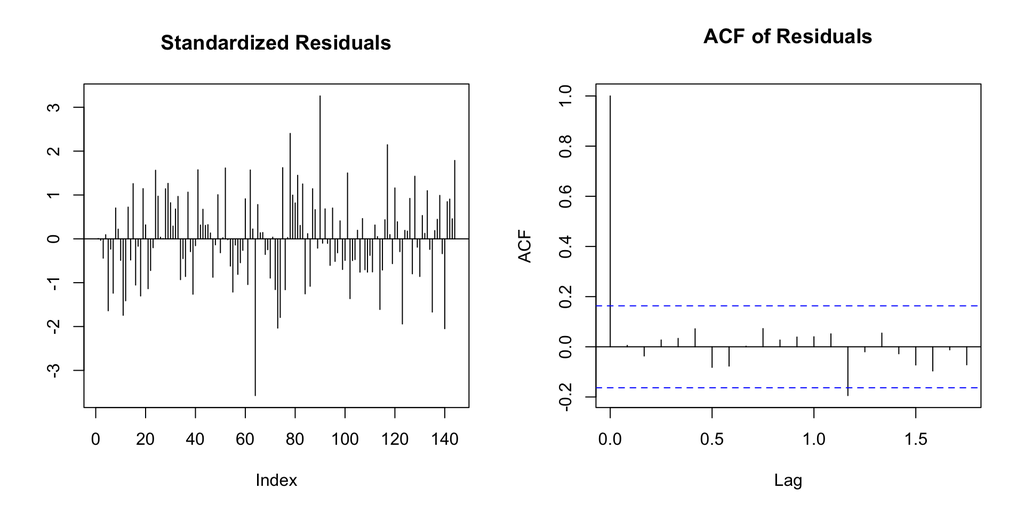

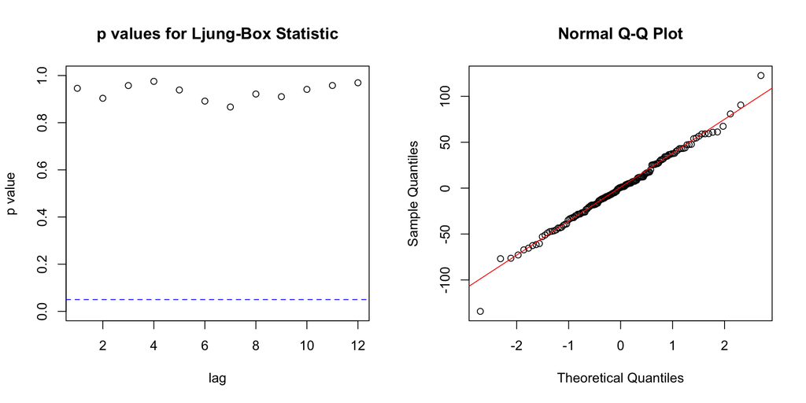

```r
par(mfrow = c(1, 2))
plot(scale(arima021$residuals), type = "h", ylab = "", main = "Standardized Residuals")
abline(h = 0)
acf(arima021$residuals, main = "ACF of Residuals")
plot(x = 1:12,
     y = sapply(1:12, function(x) Box.test(arima021$residuals, type = "Ljung-Box", lag = x)$p.value),
     main = "p values for Ljung-Box Statistic",
     xlab = "lag",
     ylab = "p value",
     ylim = c(0, 1))
abline(h = 0.05, lty = 2, col = "blue")
qqnorm(arima021$residuals)
qqline(arima021$residuals, col = "red")
```

#### f) Forecast

The prediction the Dow-Jones industrial index for Aug 1980 and Aug 1981 and their corresponding 90% prediction intervals are showed below. Plot show focast, prediction interval and real value of the thirteen monthes.

```
##          Real.Value Point.Forecast    Lo.90     Hi.90
## Aug 1980     932.59       935.5949 873.3123  997.8775
## Aug 1981     881.47       938.8939 705.1612 1172.6266
```

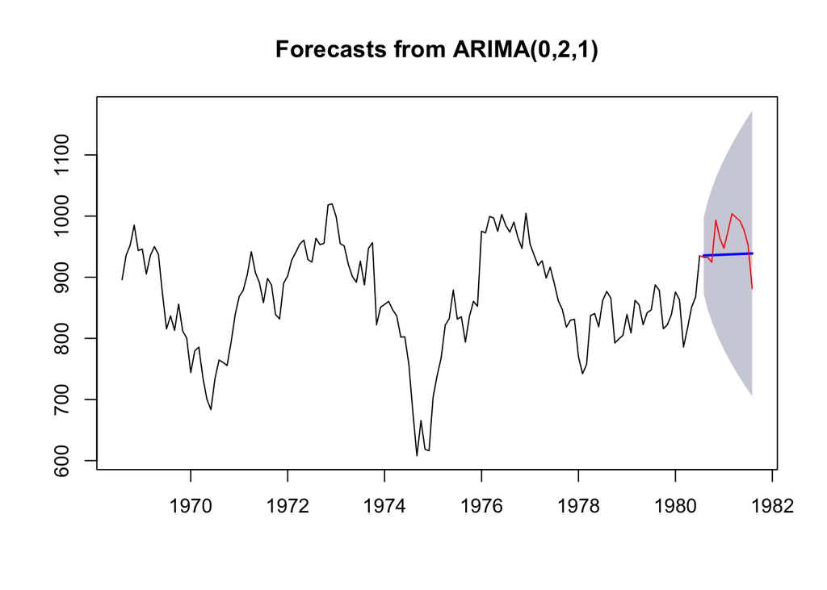

```r
library(forecast)
DJ.fcst <- forecast(arima021, h = 13, level = 90)
plot(DJ.fcst)
lines(DJ.test.ts, col = "red")
DJ.fcst.point <- data.frame(Real.Value = DJ.test.ts[-1], Point.Forecast = DJ.fcst$mean, Lo.90 = DJ.fcst$lower[,1], Hi.90 = DJ.fcst$upper[,1])[c(1,13),]
row.names(DJ.fcst.point) <- c("Aug 1980", "Aug 1981")
DJ.fcst.point
```

#### g) Conclusion

The prediction result of Aug 1980 by ARIMA(0,2,1) are close to the real values, suggest a relative good predictive power of the obtained model, while forecast on Aug 1981 deviate much more, because ARIMA model is only suitable for short-term forecast. In general, we have shown that using ARIMA model to predict short-term Dow-Jones industrial index is possible.